# Weeks 2-3 Residential Dataset Validation and Market Analysis

**IDX Exchange Data Analyst Internship**  
**Analysis period:** January 2024 through June 2026

Week 2 covers dataset validation and Week 3 covers exploratory analysis and mortgage-rate enrichment. All market results are limited to **Residential properties**, following the team's approved scope.

```python
from pathlib import Path

import matplotlib.pyplot as plt
import pandas as pd
from IPython.display import HTML, Image, display


ROOT = Path.cwd()
if ROOT.name == "notebooks":
    ROOT = ROOT.parent

ANALYSIS_DIR = ROOT / "data" / "analysis"
VALIDATION_DIR = ROOT / "data" / "validation"
ENRICHED_DIR = ROOT / "data" / "enriched"

COLORS = {
    "ink": "#1F2937",
    "teal": "#0F766E",
    "blue": "#1F6B8C",
    "amber": "#D97706",
    "red": "#B91C1C",
    "green": "#15803D",
    "gray": "#6B7280",
}

pd.set_option("display.max_columns", 30)
pd.set_option("display.float_format", lambda value: f"{value:,.2f}")
```

```python
market = pd.read_csv(ANALYSIS_DIR / "market_summary.csv")
counties = pd.read_csv(ANALYSIS_DIR / "county_price_summary.csv")
numeric = pd.read_csv(ANALYSIS_DIR / "numeric_distribution_summary.csv")
mortgage = pd.read_csv(ENRICHED_DIR / "mortgage_monthly_rates.csv")
merge_validation = pd.read_csv(ENRICHED_DIR / "mortgage_merge_validation.csv")
datasets = pd.read_csv(VALIDATION_DIR / "dataset_summary.csv")
property_types = pd.read_csv(VALIDATION_DIR / "property_type_counts.csv")
field_quality = pd.read_csv(VALIDATION_DIR / "field_quality_report.csv")

required_files = {
    "market summary": market,
    "county summary": counties,
    "numeric summary": numeric,
    "mortgage rates": mortgage,
    "merge validation": merge_validation,
    "dataset summary": datasets,
    "property types": property_types,
    "field quality": field_quality,
}
assert all(not frame.empty for frame in required_files.values())

print("Weeks 2-3 report inputs loaded successfully.")
```

```
Weeks 2-3 report inputs loaded successfully.
```

## Week 2: Dataset Scope and Residential Filter

The monthly source files were first combined without removing any property types. The team then approved a Residential-only analysis scope. The filtered datasets therefore keep rows where `PropertyType == "Residential"`; the unfiltered datasets remain available for validation and comparison.

```python
scope = datasets[
    ["dataset", "rows", "columns", "residential_rows"]
].copy()
scope["residential_share_percent"] = (
    scope["residential_rows"] / scope["rows"] * 100
)
scope.columns = [
    "Dataset",
    "Rows",
    "Columns",
    "Residential Rows",
    "Residential Share (%)",
]

display(
    scope.style
    .hide(axis="index")
    .format(
        {
            "Rows": "{:,.0f}",
            "Columns": "{:,.0f}",
            "Residential Rows": "{:,.0f}",
            "Residential Share (%)": "{:.2f}%",
        }
    )
)
```

| Dataset | Rows | Columns | Residential Rows | Residential Share (%) |
| --- | --- | --- | --- | --- |
| listings_all | 967,777 | 73 | 616,072 | 63.66% |
| listings_residential | 616,072 | 73 | 616,072 | 100.00% |
| sold_all | 665,370 | 82 | 447,964 | 67.33% |
| sold_residential | 447,964 | 82 | 447,964 | 100.00% |

### Property Types Found

The original combined files include Residential Lease, Commercial, Land, and other property types. Only Residential records are included in the analysis.

```python
property_type_review = property_types[
    property_types["dataset"].isin(["listings_all", "sold_all"])
].copy()
property_type_review["included_in_analysis"] = (
    property_type_review["PropertyType"].eq("Residential")
)
property_type_review.columns = [
    "Dataset",
    "Property Type",
    "Rows",
    "Percent of Dataset",
    "Included in Analysis",
]

display(
    property_type_review.style
    .hide(axis="index")
    .format(
        {
            "Rows": "{:,.0f}",
            "Percent of Dataset": "{:.2f}%",
        }
    )
)
```

| Dataset | Property Type | Rows | Percent of Dataset | Included in Analysis |
| --- | --- | --- | --- | --- |
| listings_all | BusinessOpportunity | 3,060 | 0.32% | False |
| listings_all | CommercialLease | 8,739 | 0.90% | False |
| listings_all | CommercialSale | 13,207 | 1.36% | False |
| listings_all | Land | 62,810 | 6.49% | False |
| listings_all | ManufacturedInPark | 27,567 | 2.85% | False |
| listings_all | Residential | 616,072 | 63.66% | True |
| listings_all | ResidentialIncome | 36,119 | 3.73% | False |
| listings_all | ResidentialLease | 200,203 | 20.69% | False |
| sold_all | BusinessOpportunity | 438 | 0.07% | False |
| sold_all | CommercialLease | 3,449 | 0.52% | False |
| sold_all | CommercialSale | 4,117 | 0.62% | False |
| sold_all | Land | 21,442 | 3.22% | False |
| sold_all | ManufacturedInPark | 17,954 | 2.70% | False |
| sold_all | Residential | 447,964 | 67.33% | True |
| sold_all | ResidentialIncome | 17,829 | 2.68% | False |
| sold_all | ResidentialLease | 152,177 | 22.87% | False |

## Week 2: Dataset Structure and Field Roles

The validation script reviews column data types and separates likely market analysis fields from metadata and fields needing manual review. This preserves useful identifiers and core analysis fields while keeping the review organized.

```python
type_summary = (
    field_quality.groupby(["dataset", "sample_dtype"], dropna=False)
    .size()
    .reset_index(name="field_count")
)
type_summary.columns = ["Dataset", "Sample Data Type", "Field Count"]

field_role_summary = (
    field_quality.groupby(["dataset", "field_group"], dropna=False)
    .size()
    .reset_index(name="field_count")
)
field_role_summary.columns = ["Dataset", "Field Group", "Field Count"]

display(HTML("<h3>Column data types</h3>"))
display(
    type_summary.style
    .hide(axis="index")
    .format({"Field Count": "{:,.0f}"})
)

display(HTML("<h3>Market-analysis and metadata field groups</h3>"))
display(
    field_role_summary.style
    .hide(axis="index")
    .format({"Field Count": "{:,.0f}"})
)
```

Column data types

| Dataset | Sample Data Type | Field Count |
| --- | --- | --- |
| listings_all | float64 | 28 |
| listings_all | int64 | 3 |
| listings_all | object | 3 |
| listings_all | str | 39 |
| listings_residential | float64 | 29 |
| listings_residential | int64 | 3 |
| listings_residential | object | 3 |
| listings_residential | str | 38 |
| sold_all | float64 | 32 |
| sold_all | int64 | 3 |
| sold_all | object | 7 |
| sold_all | str | 40 |
| sold_residential | float64 | 33 |
| sold_residential | int64 | 3 |
| sold_residential | object | 7 |
| sold_residential | str | 39 |

Market-analysis and metadata field groups

| Dataset | Field Group | Field Count |
| --- | --- | --- |
| listings_all | market_analysis | 44 |
| listings_all | metadata_admin | 8 |
| listings_all | review | 21 |
| listings_residential | market_analysis | 44 |
| listings_residential | metadata_admin | 8 |
| listings_residential | review | 21 |
| sold_all | market_analysis | 48 |
| sold_all | metadata_admin | 12 |
| sold_all | review | 22 |
| sold_residential | market_analysis | 48 |
| sold_residential | metadata_admin | 12 |
| sold_residential | review | 22 |

## Week 2: Missing Values and Drop-vs-Retain Review

`missing_percent` is the share of rows where a field is blank. For example, 100% missing means the column exists but has no values in that dataset version.

Two missing-value levels are intentionally shown:

- **Over 90% missing:** recommended to drop when the field does not support the Market Analysis or Competitive Analysis dashboard.
- **50% to 90% missing:** review for usefulness before keeping it in the final dashboard dataset.

Dashboard-relevant fields are retained or manually reviewed when they support required metrics, filters, comparisons, or traceability.

```python
missing_summary = (
    field_quality.groupby("dataset")
    .agg(
        total_fields=("column", "size"),
        fields_over_90_percent_missing=("over_90_percent_missing", "sum"),
        fields_50_to_90_percent_missing=(
            "between_50_and_90_percent_missing",
            "sum",
        ),
        fields_recommended_to_drop=(
            "recommended_action",
            lambda values: values.eq("drop_high_missing_field").sum(),
        ),
        optional_fields_for_review=(
            "recommended_action",
            lambda values: values.eq("review_optional_field_for_drop").sum(),
        ),
        dashboard_fields_needing_review=(
            "recommended_action",
            lambda values: values.isin(
                [
                    "review_before_drop_dashboard_field",
                    "retain_dashboard_field_review_missingness",
                ]
            ).sum(),
        ),
    )
    .reset_index()
)
missing_summary.columns = [
    "Dataset",
    "Total Fields",
    "Fields >90% Missing",
    "Fields 50%-90% Missing",
    "Drop Recommendations",
    "Optional Fields for Review",
    "Dashboard Fields for Review",
]

display(
    missing_summary.style
    .hide(axis="index")
    .format(
        {
            "Total Fields": "{:,.0f}",
            "Fields >90% Missing": "{:,.0f}",
            "Fields 50%-90% Missing": "{:,.0f}",
            "Drop Recommendations": "{:,.0f}",
            "Optional Fields for Review": "{:,.0f}",
            "Dashboard Fields for Review": "{:,.0f}",
        }
    )
)
```

| Dataset | Total Fields | Fields >90% Missing | Fields 50%-90% Missing | Drop Recommendations | Optional Fields for Review | Dashboard Fields for Review |
| --- | --- | --- | --- | --- | --- | --- |
| listings_all | 73 | 14 | 18 | 14 | 14 | 4 |
| listings_residential | 73 | 13 | 18 | 13 | 14 | 4 |
| sold_all | 82 | 14 | 13 | 14 | 13 | 0 |
| sold_residential | 82 | 15 | 12 | 15 | 12 | 0 |

```python
high_missing_residential = field_quality[
    field_quality["dataset"].isin(
        ["listings_residential", "sold_residential"]
    )
    & field_quality["over_90_percent_missing"]
][
    [
        "dataset",
        "column",
        "field_group",
        "dashboard_relevance",
        "is_core_analysis_field",
        "non_null_count",
        "missing_count",
        "missing_percent",
        "recommended_action",
    ]
].sort_values(["dataset", "missing_percent", "column"], ascending=[True, False, True])

display(HTML("<h3>Residential fields over 90% missing</h3>"))
display(
    high_missing_residential.style
    .hide(axis="index")
    .format(
        {
            "non_null_count": "{:,.0f}",
            "missing_count": "{:,.0f}",
            "missing_percent": "{:.2f}%",
        }
    )
)
```

Residential fields over 90% missing

| dataset | column | field_group | dashboard_relevance | is_core_analysis_field | non_null_count | missing_count | missing_percent | recommended_action |
| --- | --- | --- | --- | --- | --- | --- | --- | --- |
| listings_residential | AboveGradeFinishedArea | review | not_used_in_current_dashboards | False | 0 | 616,072 | 100.00% | drop_high_missing_field |
| listings_residential | BusinessType | review | not_used_in_current_dashboards | False | 0 | 616,072 | 100.00% | drop_high_missing_field |
| listings_residential | CoveredSpaces | review | not_used_in_current_dashboards | False | 0 | 616,072 | 100.00% | drop_high_missing_field |
| listings_residential | ElementarySchoolDistrict | review | not_used_in_current_dashboards | False | 0 | 616,072 | 100.00% | drop_high_missing_field |
| listings_residential | FireplacesTotal | market_analysis | possible_supporting_filter | False | 0 | 616,072 | 100.00% | drop_high_missing_field |
| listings_residential | MiddleOrJuniorSchoolDistrict | review | not_used_in_current_dashboards | False | 0 | 616,072 | 100.00% | drop_high_missing_field |
| listings_residential | TaxAnnualAmount | market_analysis | possible_supporting_filter | False | 0 | 616,072 | 100.00% | drop_high_missing_field |
| listings_residential | TaxYear | review | not_used_in_current_dashboards | False | 0 | 616,072 | 100.00% | drop_high_missing_field |
| listings_residential | BelowGradeFinishedArea | review | not_used_in_current_dashboards | False | 3,539 | 612,533 | 99.43% | drop_high_missing_field |
| listings_residential | CoBuyerAgentFirstName | review | not_used_in_current_dashboards | False | 14,497 | 601,575 | 97.65% | drop_high_missing_field |
| listings_residential | BuilderName | review | not_used_in_current_dashboards | False | 28,301 | 587,771 | 95.41% | drop_high_missing_field |
| listings_residential | LotSizeDimensions | review | not_used_in_current_dashboards | False | 32,297 | 583,775 | 94.76% | drop_high_missing_field |
| listings_residential | BuildingAreaTotal | review | not_used_in_current_dashboards | False | 55,125 | 560,947 | 91.05% | drop_high_missing_field |
| sold_residential | AboveGradeFinishedArea | review | not_used_in_current_dashboards | False | 0 | 447,964 | 100.00% | drop_high_missing_field |
| sold_residential | BusinessType | review | not_used_in_current_dashboards | False | 0 | 447,964 | 100.00% | drop_high_missing_field |
| sold_residential | CoveredSpaces | review | not_used_in_current_dashboards | False | 0 | 447,964 | 100.00% | drop_high_missing_field |
| sold_residential | ElementarySchoolDistrict | review | not_used_in_current_dashboards | False | 0 | 447,964 | 100.00% | drop_high_missing_field |
| sold_residential | FireplacesTotal | market_analysis | possible_supporting_filter | False | 0 | 447,964 | 100.00% | drop_high_missing_field |
| sold_residential | MiddleOrJuniorSchoolDistrict | review | not_used_in_current_dashboards | False | 0 | 447,964 | 100.00% | drop_high_missing_field |
| sold_residential | TaxAnnualAmount | market_analysis | possible_supporting_filter | False | 0 | 447,964 | 100.00% | drop_high_missing_field |
| sold_residential | TaxYear | review | not_used_in_current_dashboards | False | 0 | 447,964 | 100.00% | drop_high_missing_field |
| sold_residential | WaterfrontYN | market_analysis | possible_supporting_filter | False | 287 | 447,677 | 99.94% | drop_high_missing_field |
| sold_residential | BelowGradeFinishedArea | review | not_used_in_current_dashboards | False | 2,656 | 445,308 | 99.41% | drop_high_missing_field |
| sold_residential | BasementYN | market_analysis | possible_supporting_filter | False | 8,782 | 439,182 | 98.04% | drop_high_missing_field |
| sold_residential | LotSizeDimensions | review | not_used_in_current_dashboards | False | 21,816 | 426,148 | 95.13% | drop_high_missing_field |
| sold_residential | BuilderName | review | not_used_in_current_dashboards | False | 21,932 | 426,032 | 95.10% | drop_high_missing_field |
| sold_residential | BuildingAreaTotal | review | not_used_in_current_dashboards | False | 31,445 | 416,519 | 92.98% | drop_high_missing_field |
| sold_residential | CoBuyerAgentFirstName | review | not_used_in_current_dashboards | False | 41,034 | 406,930 | 90.84% | drop_high_missing_field |

```python
recommendation_counts = (
    field_quality.groupby("recommended_action")
    .size()
    .reset_index(name="field_dataset_combinations")
    .sort_values("field_dataset_combinations", ascending=False)
)
recommendation_counts.columns = [
    "Recommendation",
    "Field-Dataset Combinations",
]

dashboard_missing_review = field_quality[
    field_quality["recommended_action"].isin(
        [
            "review_before_drop_dashboard_field",
            "retain_dashboard_field_review_missingness",
        ]
    )
][
    [
        "dataset",
        "column",
        "dashboard_relevance",
        "missing_percent",
        "recommended_action",
    ]
].sort_values(["dataset", "missing_percent"], ascending=[True, False])

display(HTML("<h3>All retain/drop recommendations</h3>"))
display(
    recommendation_counts.style
    .hide(axis="index")
    .format({"Field-Dataset Combinations": "{:,.0f}"})
)

display(HTML("<h3>Dashboard fields retained or reviewed despite missingness</h3>"))
display(
    dashboard_missing_review.style
    .hide(axis="index")
    .format({"missing_percent": "{:.2f}%"})
)
```

All retain/drop recommendations

| Recommendation | Field-Dataset Combinations |
| --- | --- |
| retain_dashboard_field | 100 |
| drop_high_missing_field | 56 |
| retain_optional_supporting_field | 56 |
| review_optional_field_for_drop | 53 |
| retain_if_needed_for_traceability | 24 |
| review_if_needed_for_dashboard | 13 |
| retain_dashboard_field_review_missingness | 8 |

Dashboard fields retained or reviewed despite missingness

| dataset | column | dashboard_relevance | missing_percent | recommended_action |
| --- | --- | --- | --- | --- |
| listings_all | ClosePrice | market_analysis_dashboard | 75.08% | retain_dashboard_field_review_missingness |
| listings_all | BuyerOfficeName | competitive_analysis_dashboard | 73.50% | retain_dashboard_field_review_missingness |
| listings_all | CloseDate | market_analysis_dashboard | 72.32% | retain_dashboard_field_review_missingness |
| listings_all | PurchaseContractDate | market_analysis_dashboard | 58.73% | retain_dashboard_field_review_missingness |
| listings_residential | ClosePrice | market_analysis_dashboard | 76.63% | retain_dashboard_field_review_missingness |
| listings_residential | BuyerOfficeName | competitive_analysis_dashboard | 74.32% | retain_dashboard_field_review_missingness |
| listings_residential | CloseDate | market_analysis_dashboard | 72.71% | retain_dashboard_field_review_missingness |
| listings_residential | PurchaseContractDate | market_analysis_dashboard | 53.47% | retain_dashboard_field_review_missingness |

```python
complete_field_review = field_quality[
    [
        "dataset",
        "column",
        "sample_dtype",
        "field_group",
        "field_category",
        "dashboard_relevance",
        "is_core_analysis_field",
        "non_null_count",
        "missing_count",
        "missing_percent",
        "over_90_percent_missing",
        "between_50_and_90_percent_missing",
        "at_or_over_50_percent_missing",
        "recommended_action",
    ]
].copy()

complete_field_review["missing_percent"] = complete_field_review[
    "missing_percent"
].map(lambda value: f"{value:.2f}%")
for count_column in ["non_null_count", "missing_count"]:
    complete_field_review[count_column] = complete_field_review[
        count_column
    ].map(lambda value: f"{value:,.0f}")

complete_field_html = complete_field_review.to_html(
    index=False,
    border=0,
    classes="complete-field-review",
)
display(
    HTML(
        "<details><summary><b>Open the complete per-column field-quality "
        "review</b></summary><div style='overflow-x:auto;max-height:650px;"
        "overflow-y:auto;margin-top:10px;'>"
        + complete_field_html
        + "</div></details>"
    )
)
```

**Open the complete per-column field-quality review**

| dataset | column | sample_dtype | field_group | field_category | dashboard_relevance | is_core_analysis_field | non_null_count | missing_count | missing_percent | over_90_percent_missing | between_50_and_90_percent_missing | at_or_over_50_percent_missing | recommended_action |
| --- | --- | --- | --- | --- | --- | --- | --- | --- | --- | --- | --- | --- | --- |
| listings_all | FireplacesTotal | float64 | market_analysis | property_detail | possible_supporting_filter | False | 0 | 967,777 | 100.00% | True | False | True | drop_high_missing_field |
| listings_all | AboveGradeFinishedArea | float64 | review | needs_manual_review | not_used_in_current_dashboards | False | 0 | 967,777 | 100.00% | True | False | True | drop_high_missing_field |
| listings_all | CoveredSpaces | float64 | review | needs_manual_review | not_used_in_current_dashboards | False | 0 | 967,777 | 100.00% | True | False | True | drop_high_missing_field |
| listings_all | ElementarySchoolDistrict | float64 | review | needs_manual_review | not_used_in_current_dashboards | False | 0 | 967,777 | 100.00% | True | False | True | drop_high_missing_field |
| listings_all | MiddleOrJuniorSchoolDistrict | float64 | review | needs_manual_review | not_used_in_current_dashboards | False | 0 | 967,777 | 100.00% | True | False | True | drop_high_missing_field |
| listings_all | TaxYear | float64 | review | needs_manual_review | not_used_in_current_dashboards | False | 980 | 966,797 | 99.90% | True | False | True | drop_high_missing_field |
| listings_all | BelowGradeFinishedArea | float64 | review | needs_manual_review | not_used_in_current_dashboards | False | 3,976 | 963,801 | 99.59% | True | False | True | drop_high_missing_field |
| listings_all | BusinessType | str | review | needs_manual_review | not_used_in_current_dashboards | False | 6,700 | 961,077 | 99.31% | True | False | True | drop_high_missing_field |
| listings_all | TaxAnnualAmount | float64 | market_analysis | price | possible_supporting_filter | False | 6,938 | 960,839 | 99.28% | True | False | True | drop_high_missing_field |
| listings_all | CoBuyerAgentFirstName | str | review | needs_manual_review | not_used_in_current_dashboards | False | 20,508 | 947,269 | 97.88% | True | False | True | drop_high_missing_field |
| listings_all | BuilderName | str | review | needs_manual_review | not_used_in_current_dashboards | False | 32,791 | 934,986 | 96.61% | True | False | True | drop_high_missing_field |
| listings_all | LotSizeDimensions | str | review | needs_manual_review | not_used_in_current_dashboards | False | 55,392 | 912,385 | 94.28% | True | False | True | drop_high_missing_field |
| listings_all | ElementarySchool | str | review | needs_manual_review | not_used_in_current_dashboards | False | 90,090 | 877,687 | 90.69% | True | False | True | drop_high_missing_field |
| listings_all | MiddleOrJuniorSchool | str | review | needs_manual_review | not_used_in_current_dashboards | False | 90,108 | 877,669 | 90.69% | True | False | True | drop_high_missing_field |
| listings_all | HighSchool | str | review | needs_manual_review | not_used_in_current_dashboards | False | 118,450 | 849,327 | 87.76% | False | True | True | review_optional_field_for_drop |
| listings_all | BuyerAgencyCompensation | float64 | metadata_admin | system_or_identifier | traceability_or_join_key | False | 123,519 | 844,258 | 87.24% | False | True | True | review_optional_field_for_drop |
| listings_all | BuyerAgencyCompensationType | str | metadata_admin | system_or_identifier | traceability_or_join_key | False | 123,538 | 844,239 | 87.23% | False | True | True | review_optional_field_for_drop |
| listings_all | BuildingAreaTotal | float64 | review | needs_manual_review | not_used_in_current_dashboards | False | 155,365 | 812,412 | 83.95% | False | True | True | review_optional_field_for_drop |
| listings_all | CoListAgentFirstName | str | review | needs_manual_review | not_used_in_current_dashboards | False | 193,302 | 774,475 | 80.03% | False | True | True | review_optional_field_for_drop |
| listings_all | CoListAgentLastName | str | review | needs_manual_review | not_used_in_current_dashboards | False | 193,859 | 773,918 | 79.97% | False | True | True | review_optional_field_for_drop |
| listings_all | CoListOfficeName | str | market_analysis | agent_office | possible_supporting_filter | False | 194,190 | 773,587 | 79.93% | False | True | True | review_optional_field_for_drop |
| listings_all | BuyerOfficeAOR | str | metadata_admin | system_or_identifier | traceability_or_join_key | False | 243,708 | 724,069 | 74.82% | False | True | True | review_optional_field_for_drop |
| listings_all | BuyerAgentFirstName | str | market_analysis | agent_office | possible_supporting_filter | False | 257,886 | 709,891 | 73.35% | False | True | True | review_optional_field_for_drop |
| listings_all | BuyerAgentMlsId | str | metadata_admin | system_or_identifier | traceability_or_join_key | False | 258,030 | 709,747 | 73.34% | False | True | True | review_optional_field_for_drop |
| listings_all | BuyerAgentLastName | str | market_analysis | agent_office | possible_supporting_filter | False | 258,837 | 708,940 | 73.25% | False | True | True | review_optional_field_for_drop |
| listings_all | AssociationFeeFrequency | str | review | needs_manual_review | not_used_in_current_dashboards | False | 281,290 | 686,487 | 70.93% | False | True | True | review_optional_field_for_drop |
| listings_all | SubdivisionName | str | review | needs_manual_review | not_used_in_current_dashboards | False | 322,504 | 645,273 | 66.68% | False | True | True | review_optional_field_for_drop |
| listings_all | MainLevelBedrooms | float64 | review | needs_manual_review | not_used_in_current_dashboards | False | 447,841 | 519,936 | 53.72% | False | True | True | review_optional_field_for_drop |
| listings_all | ClosePrice | float64 | market_analysis | price | market_analysis_dashboard | True | 241,138 | 726,639 | 75.08% | False | True | True | retain_dashboard_field_review_missingness |
| listings_all | BuyerOfficeName | str | market_analysis | agent_office | competitive_analysis_dashboard | True | 256,435 | 711,342 | 73.50% | False | True | True | retain_dashboard_field_review_missingness |

[output cut: 280 more lines]

## Week 2 Outputs

- Dataset rows, columns, data types, and property types were documented.
- Market-analysis fields were separated from metadata/review fields.
- Missing counts and percentages were calculated for every column.
- Fields over 90% missing were marked as drop recommendations when they do not support the Market Analysis or Competitive Analysis dashboards.
- Fields with 50% to 90% missing values were marked for usefulness review.
- Dashboard-relevant fields were retained or manually reviewed when partly missing.
- Residential listing and sold CSVs were saved for subsequent analysis.
- Numeric summaries were generated for the required MLS fields, including `ClosePrice`, `LivingArea`, and `DaysOnMarket`.

## Week 3: Executive Dashboard

```python
def market_value(metric, dataset="sold_residential"):
    match = market[
        market["metric"].eq(metric)
        & market["dataset"].eq(dataset)
    ]
    if match.empty:
        raise KeyError(f"Missing metric: {dataset}/{metric}")
    return float(match.iloc[0]["value"])


residential_listings = int(
    datasets.loc[datasets["dataset"].eq("listings_residential"), "rows"].iloc[0]
)
residential_sales = int(
    datasets.loc[datasets["dataset"].eq("sold_residential"), "rows"].iloc[0]
)
median_sale_price = market_value("median_close_price")
median_dom = market_value("median_days_on_market")

dashboard_html = f'''
<div style="display:grid;grid-template-columns:repeat(4,1fr);gap:14px;margin:8px 0 18px 0;">
  <div style="border-top:5px solid {COLORS["teal"]};padding:16px;background:#F7FAFA;">
    <div style="color:{COLORS["gray"]};font-size:13px;">Residential Listings</div>
    <div style="color:{COLORS["ink"]};font-size:28px;font-weight:700;">{residential_listings:,}</div>
  </div>
  <div style="border-top:5px solid {COLORS["blue"]};padding:16px;background:#F7F9FB;">
    <div style="color:{COLORS["gray"]};font-size:13px;">Residential Sales</div>
    <div style="color:{COLORS["ink"]};font-size:28px;font-weight:700;">{residential_sales:,}</div>
  </div>
  <div style="border-top:5px solid {COLORS["amber"]};padding:16px;background:#FFFBF3;">
    <div style="color:{COLORS["gray"]};font-size:13px;">Median Sale Price</div>
    <div style="color:{COLORS["ink"]};font-size:28px;font-weight:700;">${median_sale_price:,.0f}</div>
  </div>
  <div style="border-top:5px solid {COLORS["green"]};padding:16px;background:#F4FAF5;">
    <div style="color:{COLORS["gray"]};font-size:13px;">Median Days on Market</div>
    <div style="color:{COLORS["ink"]};font-size:28px;font-weight:700;">{median_dom:,.0f} days</div>
  </div>
</div>
'''
display(HTML(dashboard_html))
```

Residential Listings

616,072

Residential Sales

447,964

Median Sale Price

$825,000

Median Days on Market

18 days

```python
snapshot = pd.DataFrame(
    {
        "Metric": [
            "Average sale price",
            "Median sale price",
            "Residential share of listings",
            "Residential share of sold records",
            "Mortgage merge match rate",
        ],
        "Result": [
            f"${market_value('average_close_price'):,.0f}",
            f"${market_value('median_close_price'):,.0f}",
            f"{market_value('residential_share', 'listings_all'):.2f}%",
            f"{market_value('residential_share', 'sold_all'):.2f}%",
            f"{merge_validation['match_percentage'].min():.1f}%",
        ],
        "Interpretation": [
            "Before outlier cleaning",
            "More representative than the mean because prices are skewed",
            "Residential records retained for analysis",
            "Residential records retained for analysis",
            "No MLS rows are missing a monthly mortgage rate",
        ],
    }
)

display(
    snapshot.style
    .hide(axis="index")
    .set_properties(**{"text-align": "left", "padding": "7px"})
    .set_table_styles(
        [{"selector": "th", "props": [
            ("background-color", COLORS["ink"]),
            ("color", "white"),
            ("text-align", "left"),
            ("padding", "8px"),
        ]}]
    )
)
```

| Metric | Result | Interpretation |
| --- | --- | --- |
| Average sale price | $1,192,663 | Before outlier cleaning |
| Median sale price | $825,000 | More representative than the mean because prices are skewed |
| Residential share of listings | 63.66% | Residential records retained for analysis |
| Residential share of sold records | 67.33% | Residential records retained for analysis |
| Mortgage merge match rate | 100.0% | No MLS rows are missing a monthly mortgage rate |

## Week 3: Handbook Questions Answered

The Week 3 exploratory-analysis questions are answered below from the Residential data. Values are reported before final outlier and data-quality adjustments.

```python
dom_row = numeric[
    numeric["dataset"].eq("sold_residential")
    & numeric["field"].eq("DaysOnMarket")
].iloc[0]

top_three_counties = counties.head(3)
county_answer = "; ".join(
    f"{row.CountyOrParish}: ${row.median_close_price:,.0f}"
    for row in top_three_counties.itertuples()
)

questions_answered = pd.DataFrame(
    {
        "Handbook Question": [
            "What share of records are Residential versus other types?",
            "What are the median and average Residential ClosePrice?",
            "What is the Residential DaysOnMarket distribution?",
            "What percentage sold above, at, or below list price?",
            "Are the key transaction dates internally consistent?",
            "Which counties have the highest median sale prices?",
        ],
        "Answer": [
            (
                f"Listings: {market_value('residential_share', 'listings_all'):.2f}% "
                f"Residential and {100 - market_value('residential_share', 'listings_all'):.2f}% other. "
                f"Sold: {market_value('residential_share', 'sold_all'):.2f}% "
                f"Residential and {100 - market_value('residential_share', 'sold_all'):.2f}% other."
            ),
            (
                f"Median: ${market_value('median_close_price'):,.0f}; "
                f"average: ${market_value('average_close_price'):,.2f}."
            ),
            (
                f"Median: {market_value('median_days_on_market'):,.0f} days; "
                f"average: {market_value('average_days_on_market'):.2f} days; "
                f"95th percentile: {dom_row['p95']:,.0f} days. "
                f"{market_value('negative_days_on_market_records'):,.0f} negative records need review."
            ),
            (
                f"Above list: {market_value('sold_above_list_price'):.2f}%; "
                f"at list: {market_value('sold_at_list_price'):.2f}%; "
                f"below list: {market_value('sold_below_list_price'):.2f}%."
            ),
            (
                f"Mostly, but exceptions need review: "
                f"{market_value('listing_after_close_records'):,.0f} listing-after-close, "
                f"{market_value('purchase_after_close_records'):,.0f} purchase-after-close, and "
                f"{market_value('listing_after_purchase_records'):,.0f} listing-after-purchase records."
            ),
            county_answer,
        ],
    }
)

display(
    questions_answered.style
    .hide(axis="index")
    .set_properties(**{
        "text-align": "left",
        "white-space": "normal",
        "max-width": "650px",
        "padding": "8px",
    })
    .set_table_styles(
        [{"selector": "th", "props": [
            ("background-color", COLORS["ink"]),
            ("color", "white"),
            ("text-align", "left"),
            ("padding", "8px"),
        ]}]
    )
)
```

| Handbook Question | Answer |
| --- | --- |
| What share of records are Residential versus other types? | Listings: 63.66% Residential and 36.34% other. Sold: 67.33% Residential and 32.67% other. |
| What are the median and average Residential ClosePrice? | Median: $825,000; average: $1,192,662.74. |
| What is the Residential DaysOnMarket distribution? | Median: 18 days; average: 37.31 days; 95th percentile: 132 days. 51 negative records need review. |
| What percentage sold above, at, or below list price? | Above list: 40.05%; at list: 17.37%; below list: 42.58%. |
| Are the key transaction dates internally consistent? | Mostly, but exceptions need review: 67 listing-after-close, 239 purchase-after-close, and 290 listing-after-purchase records. |
| Which counties have the highest median sale prices? | San Mateo: $1,700,000; Santa Clara: $1,600,000; San Francisco: $1,200,000 |

## Sale-to-List Performance

The market was relatively balanced: the share of homes selling below list price was only slightly higher than the share selling above list price.

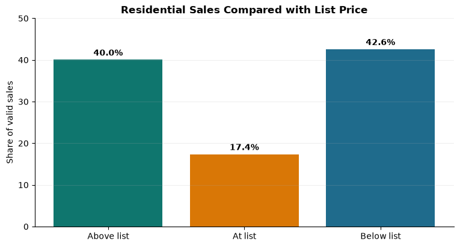

```python
sale_metrics = {
    "Above list": market_value("sold_above_list_price"),
    "At list": market_value("sold_at_list_price"),
    "Below list": market_value("sold_below_list_price"),
}

figure, axis = plt.subplots(figsize=(9, 4.5))
bars = axis.bar(
    sale_metrics.keys(),
    sale_metrics.values(),
    color=[COLORS["teal"], COLORS["amber"], COLORS["blue"]],
)
axis.set_title("Residential Sales Compared with List Price", weight="bold")
axis.set_ylabel("Share of valid sales")
axis.set_ylim(0, 50)
axis.spines[["top", "right"]].set_visible(False)
axis.grid(axis="y", alpha=0.2)

for bar, value in zip(bars, sale_metrics.values()):
    axis.text(
        bar.get_x() + bar.get_width() / 2,
        value + 1,
        f"{value:.1f}%",
        ha="center",
        weight="bold",
    )

plt.show()
```

## Price and Market-Time Distributions

The charts below display the 1st through 99th percentile range so that the main distribution remains readable. Full minimum and maximum values are documented under each chart and in the numeric appendix.

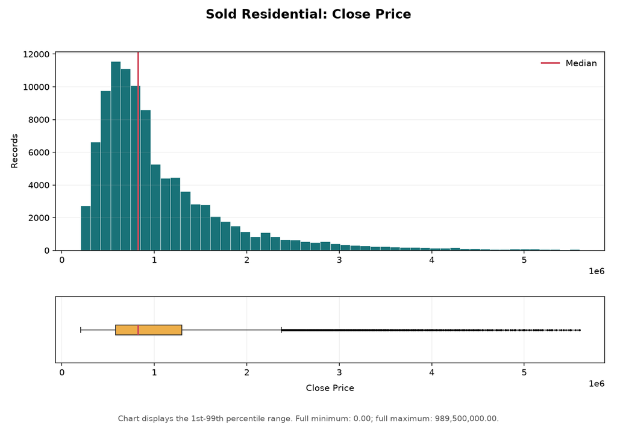

```python
display(
    Image(
        filename=str(
            ANALYSIS_DIR / "plots" / "sold_residential_ClosePrice.png"
        )
    )
)
```

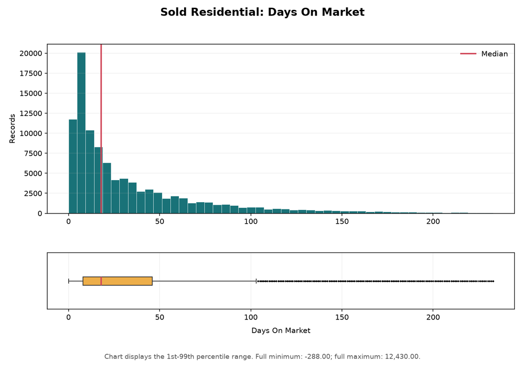

```python
display(
    Image(
        filename=str(
            ANALYSIS_DIR / "plots" / "sold_residential_DaysOnMarket.png"
        )
    )
)
```

## County Comparison

Counties are included only when they have at least 30 valid Residential sales. This prevents very small groups from dominating the ranking.

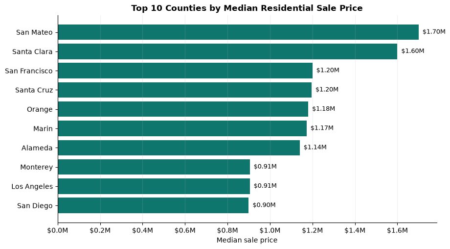

```python
top_counties = counties.head(10).sort_values("median_close_price")

figure, axis = plt.subplots(figsize=(10, 5.5))
bars = axis.barh(
    top_counties["CountyOrParish"],
    top_counties["median_close_price"],
    color=COLORS["teal"],
)
axis.set_title("Top 10 Counties by Median Residential Sale Price", weight="bold")
axis.set_xlabel("Median sale price")
axis.spines[["top", "right"]].set_visible(False)
axis.grid(axis="x", alpha=0.2)
axis.xaxis.set_major_formatter(
    lambda value, position: f"${value / 1_000_000:.1f}M"
)

for bar, value in zip(bars, top_counties["median_close_price"]):
    axis.text(
        value,
        bar.get_y() + bar.get_height() / 2,
        f"  ${value / 1_000_000:.2f}M",
        va="center",
        fontsize=9,
    )

plt.show()
```

## Mortgage-Rate Trend

Weekly FRED `MORTGAGE30US` observations were averaged by calendar month. Listings were matched using `ListingContractDate`; sold records were matched using `CloseDate`.

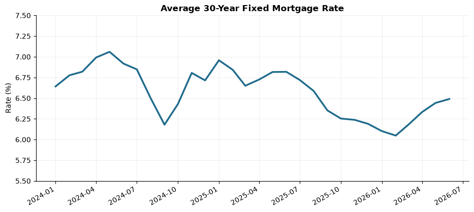

| dataset | rows | matched_rate_rows | unmatched_rate_rows | match_percentage | status |
| --- | --- | --- | --- | --- | --- |
| listings_residential | 616,072 | 616,072 | 0 | 100.0% | PASS |
| sold_residential | 447,964 | 447,964 | 0 | 100.0% | PASS |

```python
mortgage_period = mortgage[
    mortgage["year_month"].between("2024-01", "2026-06")
].copy()
mortgage_period["month"] = pd.to_datetime(
    mortgage_period["year_month"] + "-01"
)

figure, axis = plt.subplots(figsize=(11, 4.8))
axis.plot(
    mortgage_period["month"],
    mortgage_period["rate_30yr_fixed"],
    color=COLORS["blue"],
    linewidth=2.5,
)
axis.set_title("Average 30-Year Fixed Mortgage Rate", weight="bold")
axis.set_ylabel("Rate (%)")
axis.set_ylim(5.5, 7.5)
axis.spines[["top", "right"]].set_visible(False)
axis.grid(alpha=0.2)
figure.autofmt_xdate()
plt.show()

display(
    merge_validation[
        [
            "dataset",
            "rows",
            "matched_rate_rows",
            "unmatched_rate_rows",
            "match_percentage",
            "status",
        ]
    ].style.hide(axis="index").format(
        {
            "rows": "{:,.0f}",
            "matched_rate_rows": "{:,.0f}",
            "unmatched_rate_rows": "{:,.0f}",
            "match_percentage": "{:.1f}%",
        }
    )
)
```

## Data-Quality Findings

These checks identify records that may require correction or exclusion. No records were removed during Weeks 2-3.

```python
quality_checks = pd.DataFrame(
    {
        "Check": [
            "Nonpositive Close Price",
            "Negative Days on Market",
            "Listing Date After Close",
            "Purchase Date After Close",
            "Listing Date After Purchase",
            "Missing Mortgage Rate",
        ],
        "Records": [
            int(market_value("nonpositive_close_price_records")),
            int(market_value("negative_days_on_market_records")),
            int(market_value("listing_after_close_records")),
            int(market_value("purchase_after_close_records")),
            int(market_value("listing_after_purchase_records")),
            int(merge_validation["unmatched_rate_rows"].sum()),
        ],
        "Status": ["Review", "Review", "Review", "Review", "Review", "Pass"],
        "Recommended Treatment": [
            "Remove or correct",
            "Flag and investigate",
            "Add date-order flag",
            "Add date-order flag",
            "Add timeline flag",
            "No action needed",
        ],
    }
)

def status_color(value):
    if value == "Review":
        return "background-color: #FDECEC; color: #B91C1C; font-weight: bold"
    return "background-color: #EAF7EE; color: #15803D; font-weight: bold"

display(
    quality_checks.style
    .hide(axis="index")
    .format({"Records": "{:,.0f}"})
    .map(status_color, subset=["Status"])
    .set_properties(**{"text-align": "left", "padding": "7px"})
)
```

| Check | Records | Status | Recommended Treatment |
| --- | --- | --- | --- |
| Nonpositive Close Price | 1 | Review | Remove or correct |
| Negative Days on Market | 51 | Review | Flag and investigate |
| Listing Date After Close | 67 | Review | Add date-order flag |
| Purchase Date After Close | 239 | Review | Add date-order flag |
| Listing Date After Purchase | 290 | Review | Add timeline flag |
| Missing Mortgage Rate | 0 | Pass | No action needed |

## Numeric Appendix

The IQR bounds identify potential outliers for review. They are screening thresholds, not automatic deletion rules.

```python
appendix_fields = ["ClosePrice", "LivingArea", "DaysOnMarket"]
appendix = numeric[
    numeric["dataset"].eq("sold_residential")
    & numeric["field"].isin(appendix_fields)
][
    [
        "field",
        "non_null_count",
        "min",
        "median",
        "mean",
        "p99",
        "max",
        "below_iqr_bound_count",
        "above_iqr_bound_count",
    ]
].copy()

display(
    appendix.style
    .hide(axis="index")
    .format(
        {
            "non_null_count": "{:,.0f}",
            "min": "{:,.1f}",
            "median": "{:,.1f}",
            "mean": "{:,.1f}",
            "p99": "{:,.1f}",
            "max": "{:,.1f}",
            "below_iqr_bound_count": "{:,.0f}",
            "above_iqr_bound_count": "{:,.0f}",
        }
    )
)
```

| field | non_null_count | min | median | mean | p99 | max | below_iqr_bound_count | above_iqr_bound_count |
| --- | --- | --- | --- | --- | --- | --- | --- | --- |
| ClosePrice | 447,962 | 0.0 | 825,000.0 | 1,192,662.7 | 5,600,000.0 | 989,500,000.0 | 0 | 33,542 |
| DaysOnMarket | 447,964 | -288.0 | 18.0 | 37.3 | 233.0 | 12,430.0 | 8 | 34,171 |
| LivingArea | 447,711 | 0.0 | 1,646.0 | 1,904.3 | 5,287.9 | 17,021,321.0 | 0 | 19,566 |

```python
complete_numeric = numeric[
    [
        "dataset",
        "field",
        "non_null_count",
        "missing_or_non_numeric_count",
        "min",
        "p01",
        "p25",
        "median",
        "mean",
        "p75",
        "p99",
        "max",
        "below_iqr_bound_count",
        "above_iqr_bound_count",
    ]
].copy()

for count_column in [
    "non_null_count",
    "missing_or_non_numeric_count",
    "below_iqr_bound_count",
    "above_iqr_bound_count",
]:
    complete_numeric[count_column] = complete_numeric[count_column].map(
        lambda value: f"{value:,.0f}"
    )

for value_column in [
    "min",
    "p01",
    "p25",
    "median",
    "mean",
    "p75",
    "p99",
    "max",
]:
    complete_numeric[value_column] = complete_numeric[value_column].map(
        lambda value: "" if pd.isna(value) else f"{value:,.2f}"
    )

complete_numeric_html = complete_numeric.to_html(
    index=False,
    border=0,
    classes="complete-numeric-review",
)
display(
    HTML(
        "<details><summary><b>Open the complete numeric summary for all "
        "required fields</b></summary><div style='overflow-x:auto;"
        "max-height:650px;overflow-y:auto;margin-top:10px;'>"
        + complete_numeric_html
        + "</div></details>"
    )
)
```

**Open the complete numeric summary for all required fields**

| dataset | field | non_null_count | missing_or_non_numeric_count | min | p01 | p25 | median | mean | p75 | p99 | max | below_iqr_bound_count | above_iqr_bound_count |
| --- | --- | --- | --- | --- | --- | --- | --- | --- | --- | --- | --- | --- | --- |
| listings_residential | BathroomsTotalInteger | 616,015 | 57 | 0.00 | 1.00 | 2.00 | 2.00 | 2.63 | 3.00 | 7.00 | 2,208.00 | 769 | 38,468 |
| listings_residential | BedroomsTotal | 615,908 | 164 | 0.00 | 1.00 | 2.00 | 3.00 | 3.23 | 4.00 | 6.00 | 108.00 | 0 | 2,010 |
| listings_residential | ClosePrice | 143,992 | 472,080 | 525.00 | 215,000.00 | 600,000.00 | 858,000.00 | 1,212,606.87 | 1,355,000.00 | 5,585,693.00 | 820,000,000.00 | 0 | 10,609 |
| listings_residential | DaysOnMarket | 616,072 | 0 | -58.00 | 0.00 | 5.00 | 10.00 | 18.13 | 21.00 | 133.00 | 1,063.00 | 4 | 49,198 |
| listings_residential | ListPrice | 616,072 | 0 | 1.00 | 210,000.00 | 582,000.00 | 849,000.00 | 1,320,297.91 | 1,388,000.00 | 8,250,000.00 | 400,000,000.00 | 0 | 51,144 |
| listings_residential | LivingArea | 615,450 | 622 | 0.00 | 588.00 | 1,248.00 | 1,672.00 | 1,979.52 | 2,303.00 | 6,309.00 | 17,021,321.00 | 0 | 30,404 |
| listings_residential | LotSizeAcres | 565,673 | 50,399 | 0.00 | 0.00 | 0.12 | 0.17 | 60.03 | 0.32 | 13.53 | 4,187,292.00 | 0 | 90,762 |
| listings_residential | OriginalListPrice | 615,198 | 874 | 0.00 | 200,000.00 | 585,000.00 | 849,000.00 | 1,404,653.63 | 1,395,000.00 | 8,500,000.00 | 1,749,000,000.00 | 0 | 50,903 |
| listings_residential | YearBuilt | 615,009 | 1,063 | 1,776.00 | 1,911.00 | 1,961.00 | 1,980.00 | 1,979.72 | 2,001.00 | 2,025.00 | 2,028.00 | 1,542 | 0 |
| sold_residential | BathroomsTotalInteger | 447,894 | 70 | 0.00 | 1.00 | 2.00 | 2.00 | 2.54 | 3.00 | 6.00 | 175.00 | 346 | 20,412 |
| sold_residential | BedroomsTotal | 447,952 | 12 | 0.00 | 1.00 | 3.00 | 3.00 | 3.21 | 4.00 | 6.00 | 45.00 | 16,358 | 8,149 |
| sold_residential | ClosePrice | 447,962 | 2 | 0.00 | 200,502.35 | 575,000.00 | 825,000.00 | 1,192,662.74 | 1,300,000.00 | 5,600,000.00 | 989,500,000.00 | 0 | 33,542 |
| sold_residential | DaysOnMarket | 447,964 | 0 | -288.00 | 0.00 | 8.00 | 18.00 | 37.31 | 48.00 | 233.00 | 12,430.00 | 8 | 34,171 |
| sold_residential | ListPrice | 447,964 | 0 | 525.00 | 213,900.00 | 578,201.25 | 819,000.00 | 1,143,454.53 | 1,295,000.00 | 5,750,000.00 | 137,500,000.00 | 0 | 33,840 |
| sold_residential | LivingArea | 447,711 | 253 | 0.00 | 605.00 | 1,248.00 | 1,646.00 | 1,904.29 | 2,224.00 | 5,287.90 | 17,021,321.00 | 0 | 19,566 |
| sold_residential | LotSizeAcres | 413,232 | 34,732 | 0.00 | 0.00 | 0.12 | 0.17 | 62.04 | 0.27 | 10.89 | 7,810,698.36 | 0 | 64,258 |
| sold_residential | OriginalListPrice | 447,144 | 820 | 0.00 | 210,000.00 | 585,000.00 | 829,000.00 | 1,228,615.27 | 1,299,000.00 | 5,995,000.00 | 1,390,000,000.00 | 0 | 35,117 |
| sold_residential | YearBuilt | 447,564 | 400 | 1,776.00 | 1,912.00 | 1,960.00 | 1,979.00 | 1,978.62 | 1,999.00 | 2,025.00 | 2,027.00 | 1,063 | 0 |

## Complete Numeric Distribution Plot Appendix

Residential Listings

ClosePrice

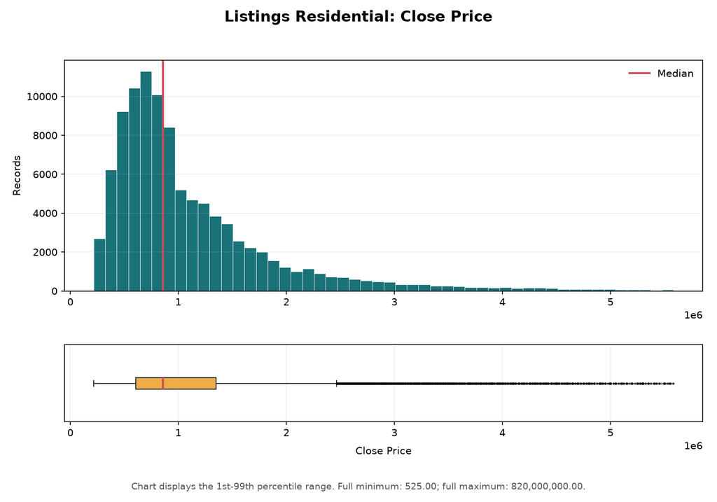

ListPrice

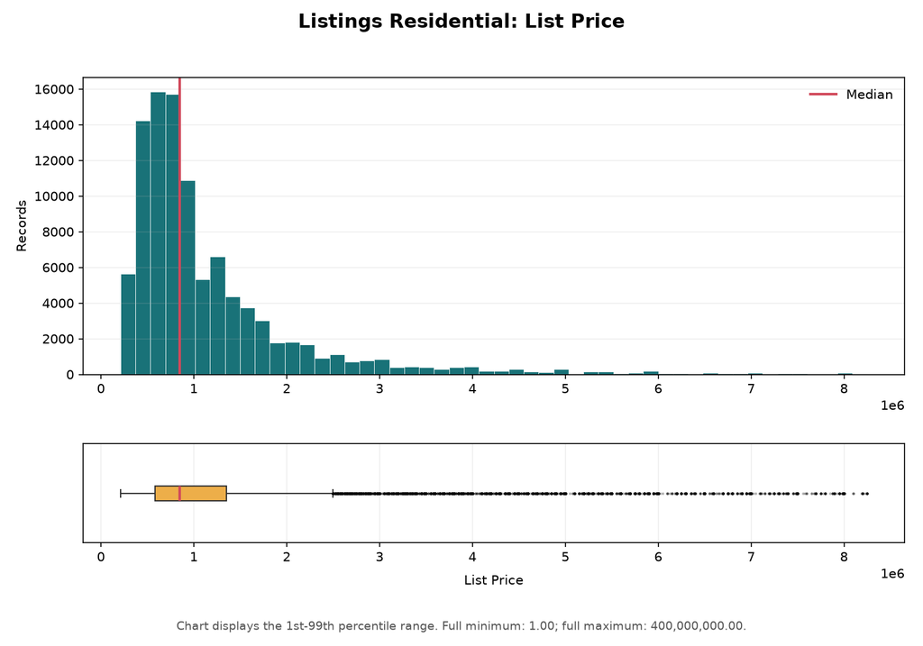

OriginalListPrice

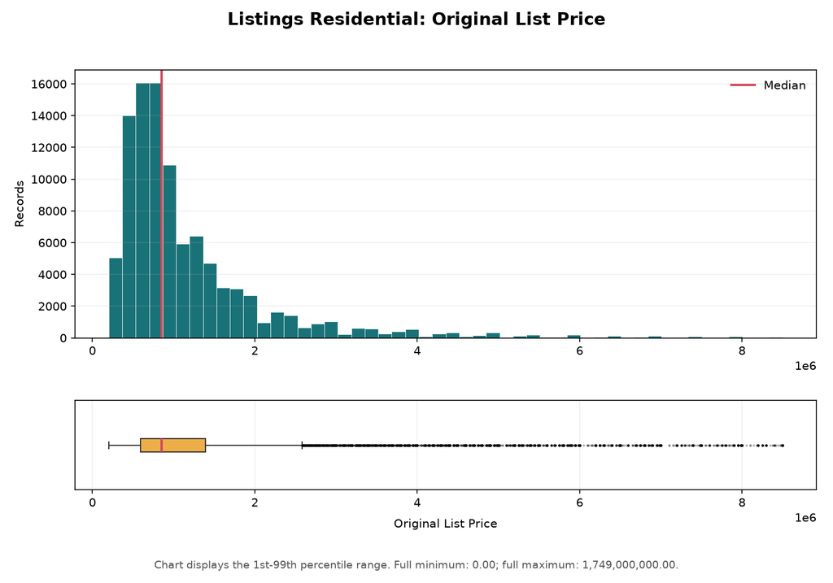

LivingArea

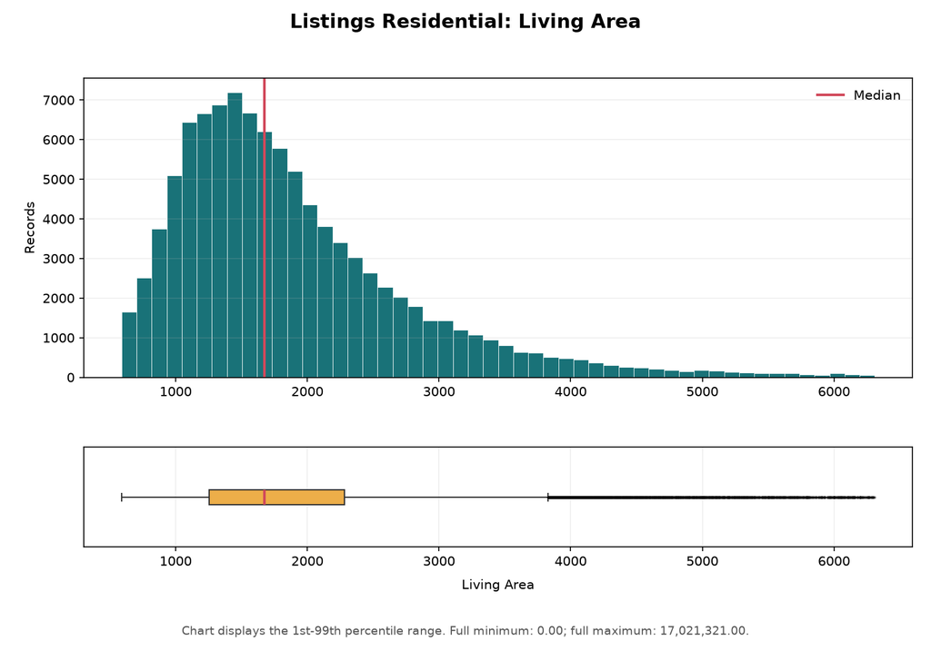

LotSizeAcres

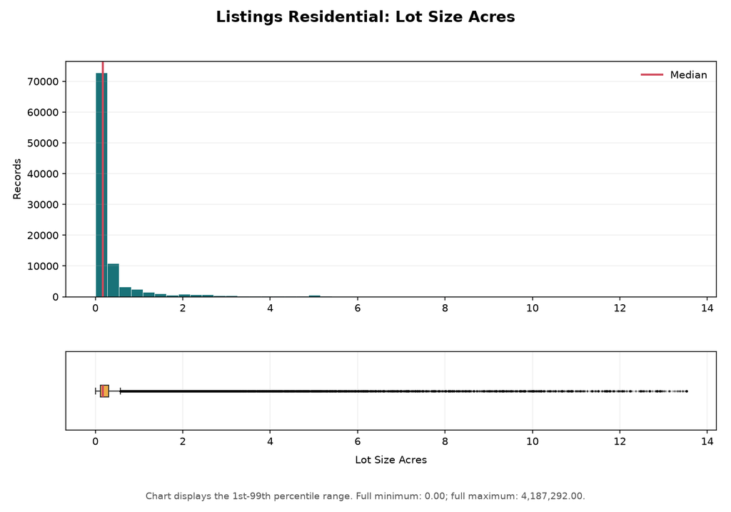

BedroomsTotal

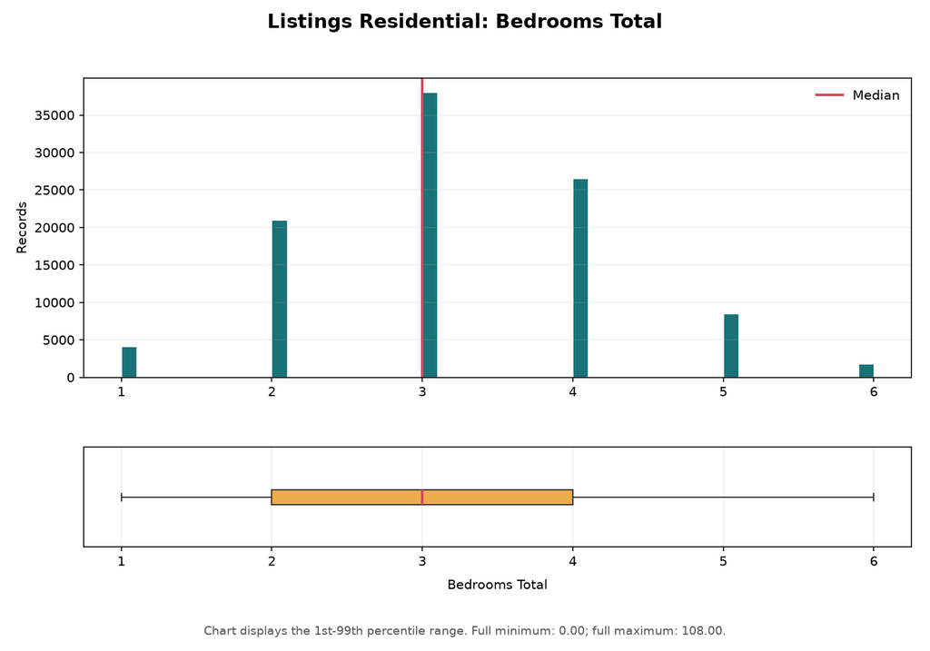

BathroomsTotalInteger

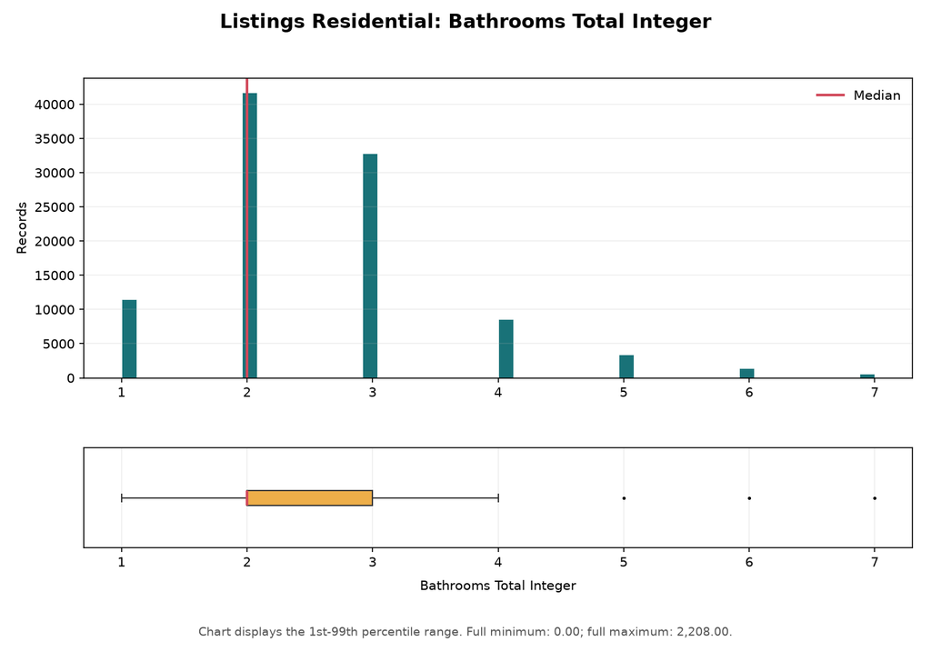

DaysOnMarket

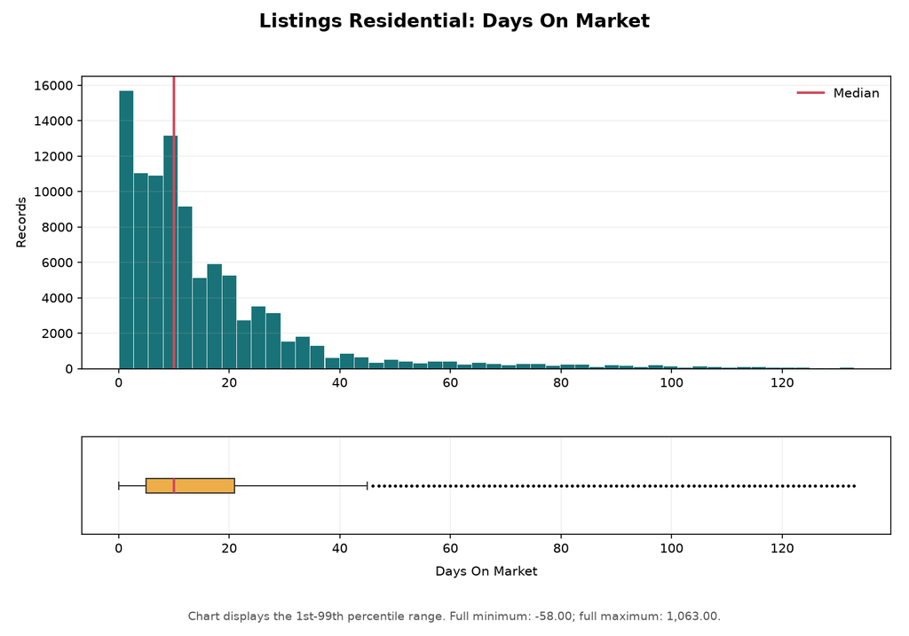

YearBuilt

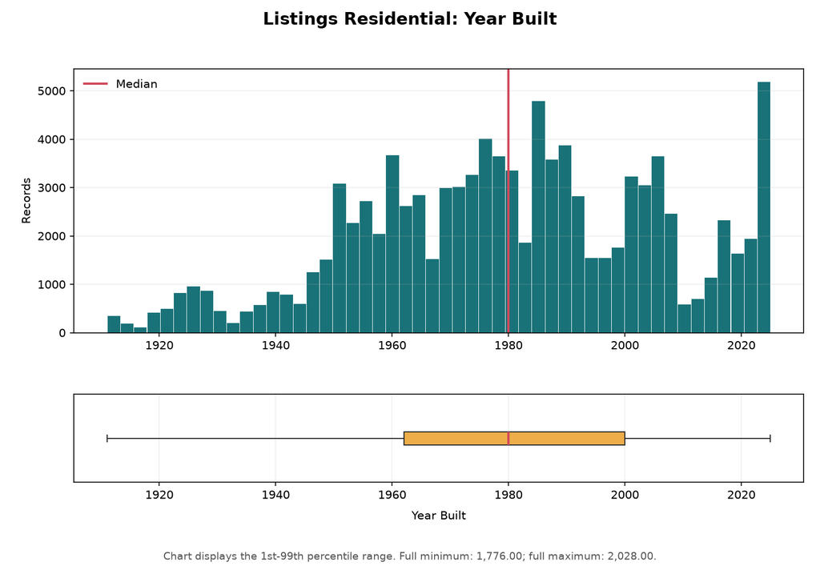

Residential Sold

ClosePrice

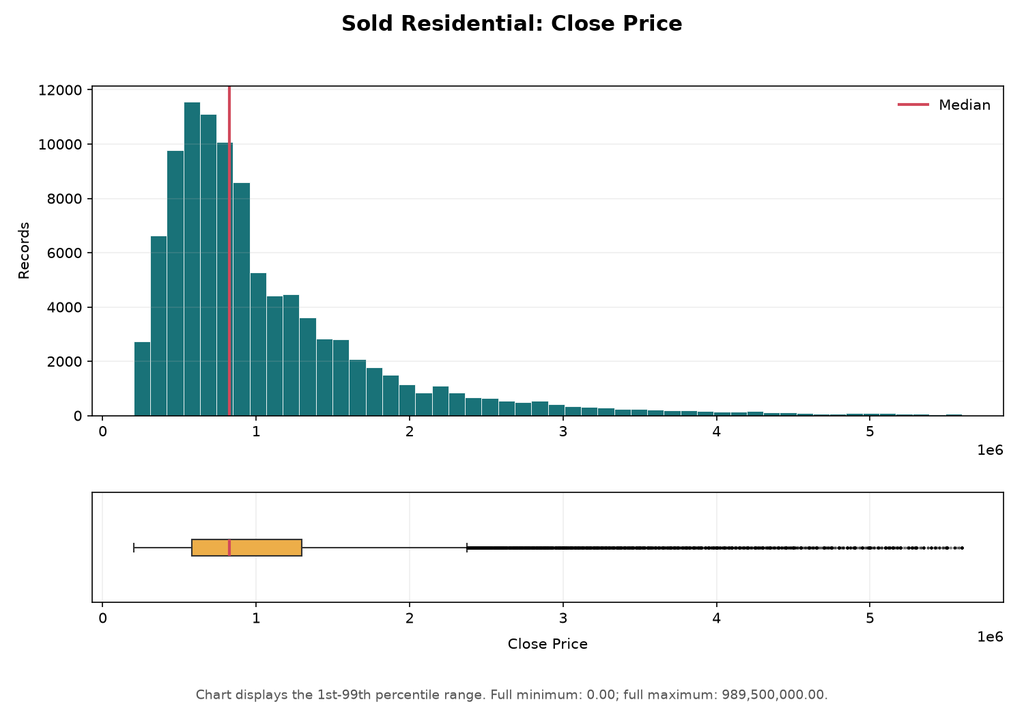

ListPrice

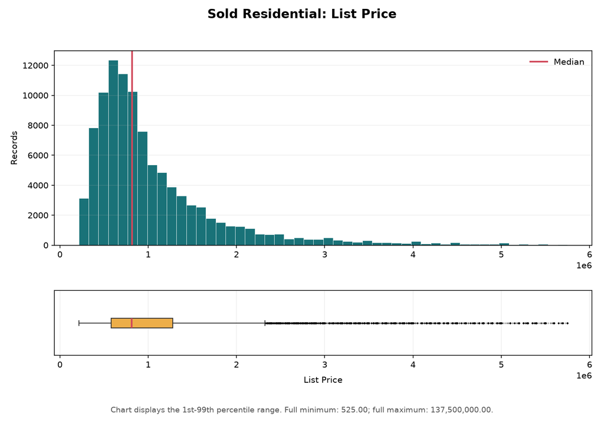

OriginalListPrice

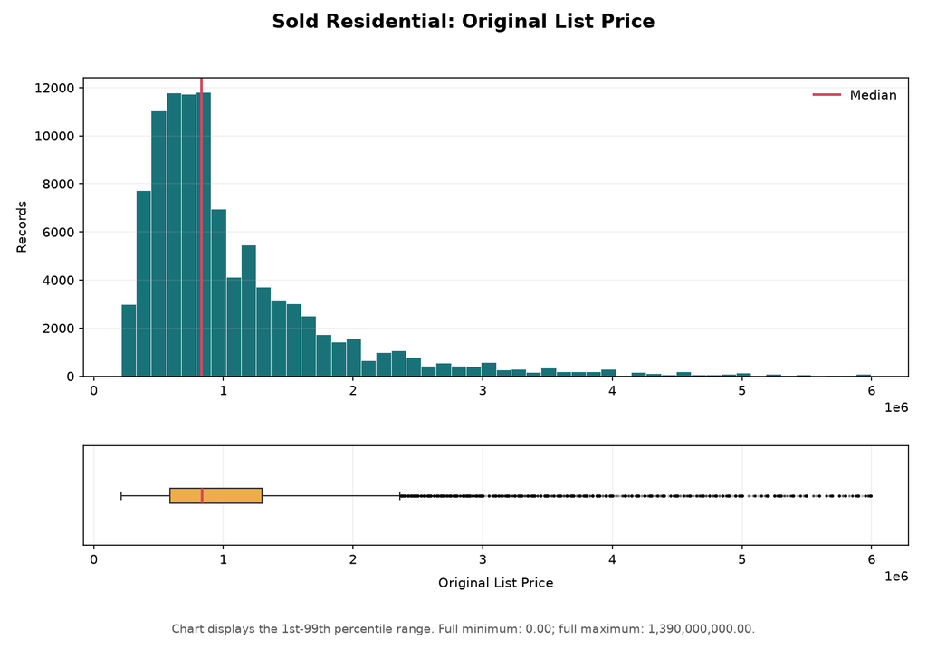

LivingArea

[6 more figures not shown]

```python
plot_fields = [
    "ClosePrice",
    "ListPrice",
    "OriginalListPrice",
    "LivingArea",
    "LotSizeAcres",
    "BedroomsTotal",
    "BathroomsTotalInteger",
    "DaysOnMarket",
    "YearBuilt",
]

for dataset_name, dataset_label in [
    ("listings_residential", "Residential Listings"),
    ("sold_residential", "Residential Sold"),
]:
    display(HTML(f"<h3>{dataset_label}</h3>"))
    for field in plot_fields:
        display(HTML(f"<h4>{field}</h4>"))
        display(
            Image(
                filename=str(
                    ANALYSIS_DIR
                    / "plots"
                    / f"{dataset_name}_{field}.png"
                )
            )
        )
```

## Sources

- CRMLS monthly listing and sold files, January 2024 through June 2026
- Federal Reserve Bank of St. Louis `MORTGAGE30US` series